# Kaggle Report

Suzy Gao

12/3/2018

## Introduction:

This is an individual project for Airbnb NYC rental price prediction using over 90 vairables on the property, host, and past reviews. I will use Linear Regression and Trees to create models predicting Airbnb rental price using attributes in the given dataset. At the end of this report, I will be comparing the prediction result based on different techniques, and a list of submission will be attached for reference.

## 1. Exploring the Data

```r
train= read.csv('analysisData.csv')
test = read.csv('scoringData.csv')
```

```r
# Look at the structure of the data
dim(train)
head(train, n=1)
dim(test)
head(test, n =1)
```

##### The train data set has 29142 rows and 96 features, the test data set has 7286 rows and 95 features.

```r
# Now take a look at the number of different types of data in train data set.
table(sapply(train,class))
# The percentage of data missing in train
sum(is.na(train)) / (nrow(train) *ncol(train))
# The percentage of data missing in test
sum(is.na(train)) / (nrow(train) *ncol(train))
```

```r
# Let's take a look at the distribution of our target variable
summary(train$price)
quantile(train$price)
```

#### From Histogram, we could see that it deviates from normal distribution and has positive skewness.

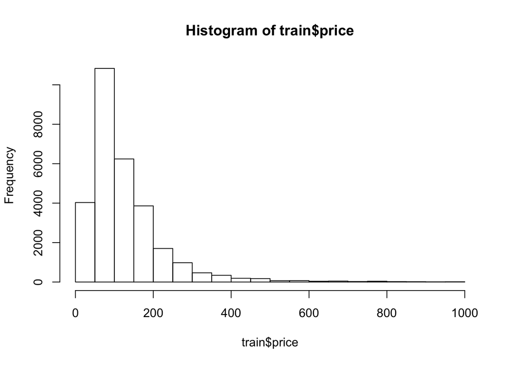

##### Therefore,I will do log transformation to normalize price

## 2. Preparing the Data for Analysis

### Firstly, remove the useless data.

Since the real-world data is very dirty and unorganized, the first thing is to remove thoes that are obviously useless for us or they are too dirty to use. I defined them as “removable” based the following conditions:

1. Spread out too wide
2. Implausible or illogical values
3. Features have single value for all rows that do not affact the result

```r
# When I look at the variables, the following seemed useless to me, so that I can remove them
library(dplyr)
train <- select(train, -jurisdiction_names,-picture_url,-host_acceptance_rate,-host_thumbnail_url,-host_picture_url,-first_review,-last_review,-requires_license,-license,country,-country_code,-has_availability,-calendar_last_scraped,-listing_url,-scrape_id,-last_scraped,-name,-summary,-space,-experiences_offered,-neighborhood_overview,-notes,-transit,-access,-interaction,-house_rules,-thumbnail_url,-medium_url,-xl_picture_url,-host_id,-host_url,-host_name,-host_since,-host_about,-require_guest_phone_verification, -require_guest_profile_picture,-host_has_profile_pic)
```

##### 36 variables are removed

### Secondly, clean the data

```r
# Count the character of each description, adding charCountDescription train data set
train$description = as.character(train$description)
train$charCountDescription = nchar(train$description)

# Now I can delete it since I am not going to use desciption itself for prediction anymore.
train$description = NULL

# Do the same on test data
test$description = as.character(test$description)
test$charCountDescription = nchar(test$description)
test$description = NULL

#count number of amenities and host_verifications
train$newcolumn1 <- NA
colnames(train)[colnames(train)=="newcolumn1"] <- "num_amenities"
train$num_amenities<-sapply(strsplit(as.character(train$amenities)," "),length)

train$newcolumn2 <- NA
colnames(train)[colnames(train)=="newcolumn2"] <- "num_host_verifications"
train$num_host_verifications<-sapply(strsplit(as.character(train$host_verifications)," "),length)

library(dplyr)
train <- select(train, -amenities, -host_verifications)

# And repeat the same steps for test data set
```

##### Since location should have serious impacts on Airbnb rental price, I want to furthur explore the geographic variables.

```r
# For street
as.data.frame(table(train$street))
as.data.frame(table(test$street))

# For city
as.data.frame(table(train$city))
as.data.frame(table(test$city))
```

##### It is not hard to see that data in both street and city spread out too widely, which means they are too “dirty” and not worth studying.

##### Similar for vairable host_location and smart_location.

```r
# For market and state
as.data.frame(table(train$market))
as.data.frame(table(train$state))
```

##### Over 95% of them are the same, so I can also remove these variables. For host_neighbourhood, since there are too many unmatched levels between train and test data set, I will also remove them.

```r
train <- select(train, -street, -city, -state, -market, -host_location, -smart_location, - host_neighbourhood)
```

### Thirdly, dealing with Missing values

```r
# View the summary statistics of all variables that contains NA values
temp <- sapply(train, function(x)  sum(is.na(x)))
miss <- sort(temp, decreasing=T)
miss[miss>0]
```

```
##    monthly_price      square_feet     weekly_price security_deposit
##            28901            28801            25307            11827
##     cleaning_fee             beds
##             5702               17
```

```r
summary(train[,names(miss)[miss>0]])
```

```
##  monthly_price    square_feet      weekly_price   security_deposit
##  Min.   :470.0   Min.   :   0.0   Min.   :100.0   Min.   :  0.0
##  1st Qu.:800.0   1st Qu.: 320.0   1st Qu.:400.0   1st Qu.:  0.0
##  Median :890.0   Median : 700.0   Median :550.0   Median :150.0
##  Mean   :853.7   Mean   : 726.4   Mean   :571.2   Mean   :189.9
##  3rd Qu.:930.0   3rd Qu.: 950.0   3rd Qu.:724.5   3rd Qu.:300.0
##  Max.   :999.0   Max.   :5000.0   Max.   :999.0   Max.   :999.0
##  NA's   :28901   NA's   :28801    NA's   :25307   NA's   :11827
##   cleaning_fee         beds
##  Min.   :  0.00   Min.   : 1.000
##  1st Qu.: 25.00   1st Qu.: 1.000
##  Median : 50.00   Median : 1.000
##  Mean   : 58.15   Mean   : 1.588
##  3rd Qu.: 80.00   3rd Qu.: 2.000
##  Max.   :500.00   Max.   :21.000
##  NA's   :5702     NA's   :17
```

```r
train <- select(train,  -monthly_price, -square_feet, -weekly_price)
```

```r
# View summary statistics of missing values in test data set
temp1 <- sapply(test, function(x)  sum(is.na(x)))
miss <- sort(temp1, decreasing=T)
miss[miss>0]
```

```
##     thumbnail_url        medium_url    xl_picture_url           license
##              7286              7286              7286              7286
##     monthly_price       square_feet      weekly_price  security_deposit
##              7233              7176              6337              2888
##      cleaning_fee           zipcode              beds reviews_per_month
##              1402                93                 2                 1
```

```r
summary(test[,names(miss)[miss>0]])
```

```
##  thumbnail_url  medium_url     xl_picture_url license
##  Mode:logical   Mode:logical   Mode:logical   Mode:logical
##  NA's:7286      NA's:7286      NA's:7286      NA's:7286
##
##
##
##
##
##  monthly_price   square_feet      weekly_price   security_deposit
##  Min.   :625    Min.   :   0.0   Min.   :180.0   Min.   :  0.0
##  1st Qu.:800    1st Qu.: 209.5   1st Qu.:400.0   1st Qu.:  0.0
##  Median :900    Median : 625.0   Median :550.0   Median :150.0
##  Mean   :867    Mean   : 630.6   Mean   :573.5   Mean   :195.6
##  3rd Qu.:950    3rd Qu.: 850.0   3rd Qu.:725.0   3rd Qu.:300.0
##  Max.   :999    Max.   :2000.0   Max.   :999.0   Max.   :995.0
##  NA's   :7233   NA's   :7176     NA's   :6337    NA's   :2888
##   cleaning_fee       zipcode           beds        reviews_per_month
##  Min.   :  0.00   Min.   :10001   Min.   : 1.000   Min.   : 0.020
##  1st Qu.: 25.00   1st Qu.:10024   1st Qu.: 1.000   1st Qu.: 0.250
##  Median : 50.00   Median :11103   Median : 1.000   Median : 0.720
##  Mean   : 59.02   Mean   :10662   Mean   : 1.609   Mean   : 1.282
##  3rd Qu.: 80.00   3rd Qu.:11221   3rd Qu.: 2.000   3rd Qu.: 1.880
##  Max.   :500.00   Max.   :11693   Max.   :13.000   Max.   :20.180
##  NA's   :1402     NA's   :93      NA's   :2        NA's   :1
```

#### Impute the missing values for both train and test data set, replace “NA”s with means, and convert them to numeric variables

```r
# Beds
train$beds[is.na(train$beds)] <- mean(train$beds, na.rm = T)
test$beds[is.na(test$beds)] <- mean(test$beds, na.rm = T)

# Convert them to numeric
train$beds <- as.numeric(train$beds)
test$beds <- as.numeric(test$beds)

# For security_deposit and cleaning_fee
summary(train$cleaning_fee)
```

```
##    Min. 1st Qu.  Median    Mean 3rd Qu.    Max.    NA's
##    0.00   25.00   50.00   58.15   80.00  500.00    5702
```

```r
train$cleaning_fee[is.na(train$cleaning_fee)] <- mean(train$cleaning_fee,na.rm = T)
summary(test$cleaning_fee)
```

```
##    Min. 1st Qu.  Median    Mean 3rd Qu.    Max.    NA's
##    0.00   25.00   50.00   59.02   80.00  500.00    1402
```

```r
test$cleaning_fee[is.na(test$cleaning_fee)] <- mean(test$cleaning_fee,na.rm = T)
train$cleaning_fee <- as.numeric(train$cleaning_fee)
test$cleaning_fee <- as.numeric(test$cleaning_fee)

summary(train$security_deposit)
```

```
##    Min. 1st Qu.  Median    Mean 3rd Qu.    Max.    NA's
##     0.0     0.0   150.0   189.9   300.0   999.0   11827
```

```r
train$security_deposit[is.na(train$security_deposit)] <- mean(train$security_deposit,na.rm = T)
summary(test$security_deposit)
```

```
##    Min. 1st Qu.  Median    Mean 3rd Qu.    Max.    NA's
##     0.0     0.0   150.0   195.6   300.0   995.0    2888
```

```r
test$security_deposit[is.na(test$security_deposit)] <- mean(test$security_deposit,na.rm = T)

# For review_per_month in test data set
summary(test$reviews_per_month)
```

```
##    Min. 1st Qu.  Median    Mean 3rd Qu.    Max.    NA's
##   0.020   0.250   0.720   1.282   1.880  20.180       1
```

```r
test$reviews_per_month[is.na(test$reviews_per_month)] <- mean(test$reviews_per_month,na.rm = T)
test$reviews_per_month <- as.numeric(test$reviews_per_month)
```

#### Reducing factor levels by grouping different levels together

```r
str(train)
# I found 5 categorical variables with more than 50 levels: host_response_rate,neighbourhood, neighbourhood_cleansed, zipcode, calendar_updated

# For calendar_updated
levels(train$calendar_updated)
levels(train$calendar_updated)[c(1:4,12:14,25:27,38:40,48:50,53:60,62:63)] <- "within 12 months"
levels(train$calendar_updated)
levels(train$calendar_updated)[c(2:13)] <- "13 to 24 months"
levels(train$calendar_updated)[c(3:14)] <- "25 to 36 months"
levels(train$calendar_updated)[c(4:13)] <- "37 to 48 months"
levels(train$calendar_updated)[c(5:6)] <- "more than 48 months"

# Do the same for claendar_updated on test data set
```

## 3.Data Visualization

### Explore the correlations (Interger)

[figure not shown]

#### Display the lower part

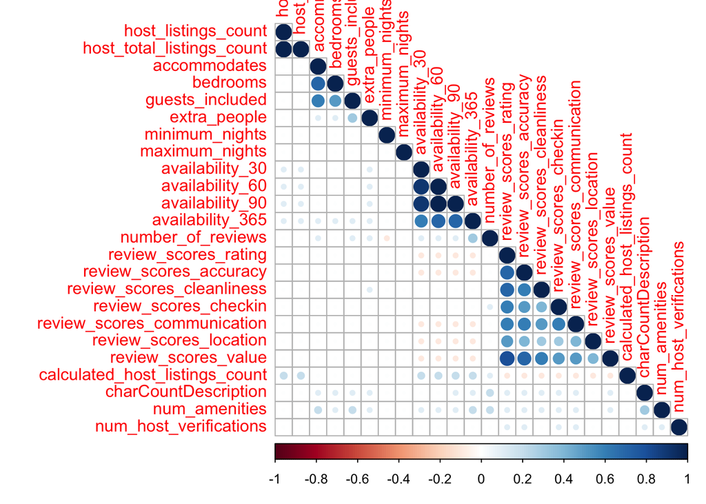

#### Display the upper part

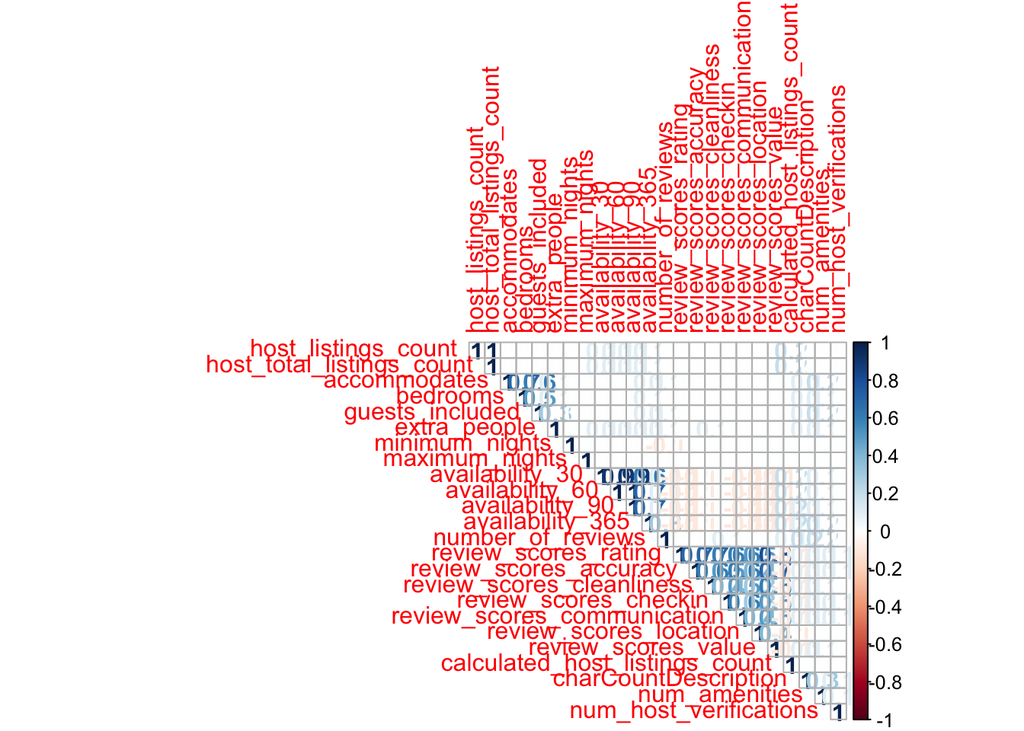

### Exploring the correlation (Numeric variables)

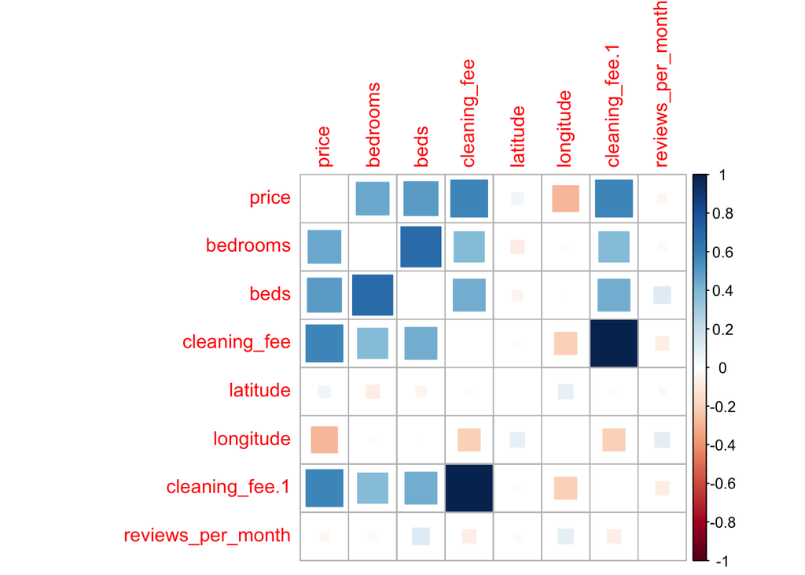

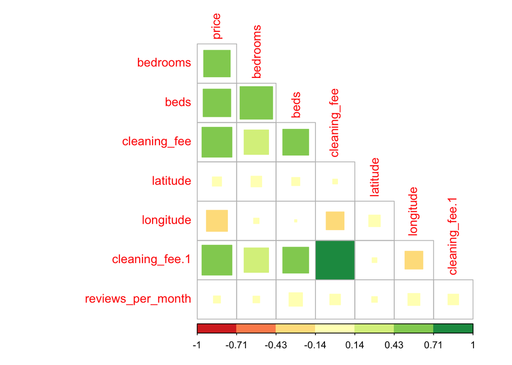

### Plotting cleaning_fee to see if there is any outliers

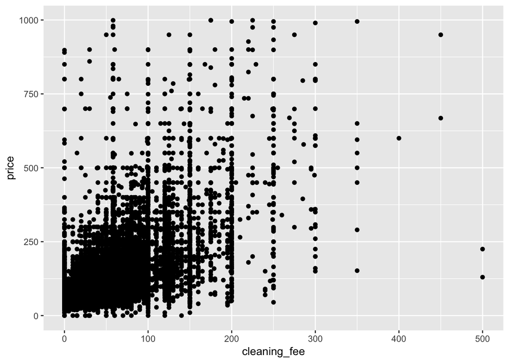

```r
# There are outliers in 'cleaning_fee' field. Let's remove those outliers.
train <- train[train$cleaning_fee<=300,]
```

##### Now that my data is much cleaner and it’s ready to build the prediction models!

## 4.Modeling Techniques

#### Simple Linear Model

```r
# Building the first linear model (RMSE 61.23777)
model1 = lm(price~ bathrooms+bedrooms*beds+cleaning_fee*guests_included*accommodates+room_type+property_type+longitude*latitude*neighbourhood+minimum_nights+review_scores_rating*review_scores_value+number_of_reviews*review_scores_communication+availability_60*availability_365+host_identity_verified+neighbourhood_cleansed+review_scores_location+calendar_updated+calculated_host_listings_count+charCountDescription+security_deposit+zipcode+host_response_time+num_amenities+num_host_verifications,data = train)
```

##### Plotting some graphs to examine accuracy and residuals

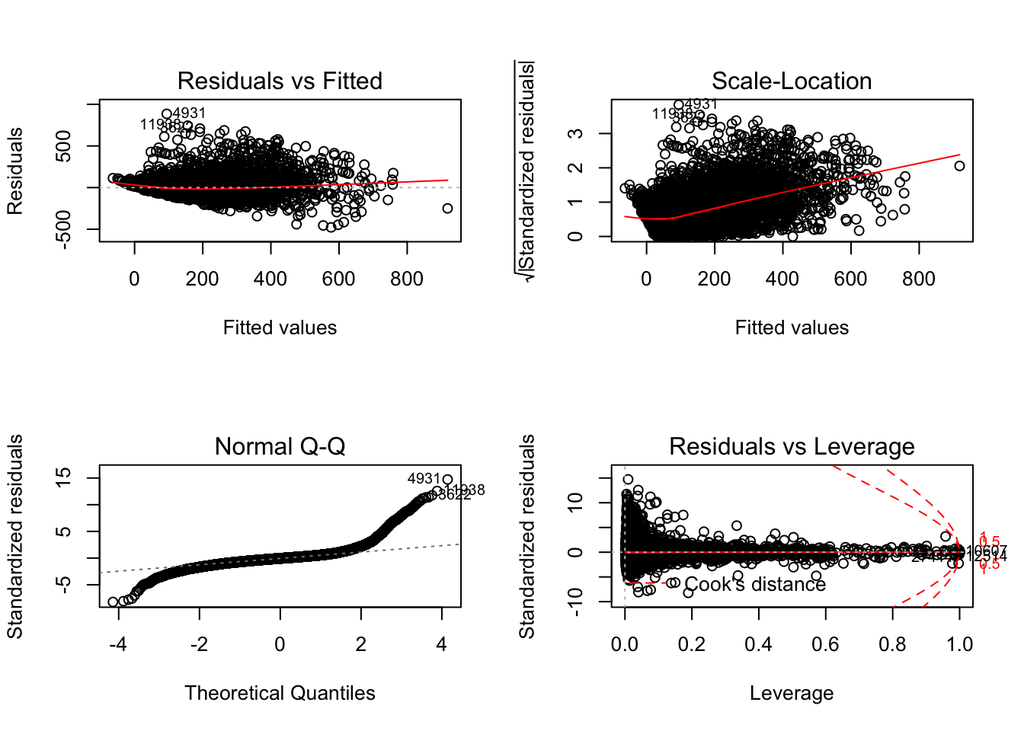

##### Removing outliers by looking at the distance from “cook”"

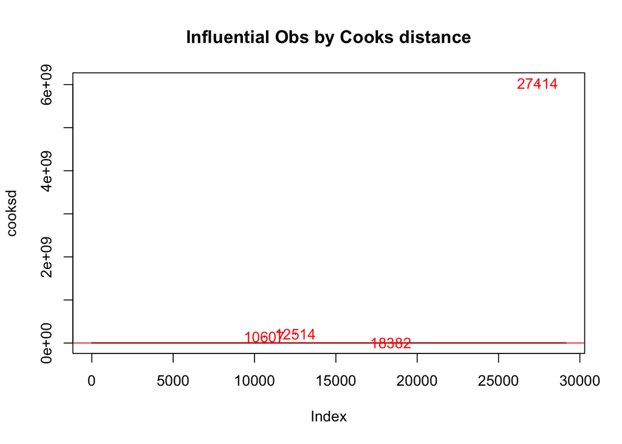

```r
# Since price contains zero values, I first need to change replace them with 0.0001, which would have little impact on the original data
summary(train$price)
train$price[train$price == "0"] <- "0.0001"
train$price <- as.numeric(train$price)

model2 = lm(log(price)~ bathrooms+bedrooms*beds+cleaning_fee*guests_included+room_type+property_type+longitude*latitude*neighbourhood+minimum_nights+accommodates+review_scores_rating*review_scores_value+number_of_reviews*review_scores_communication+availability_60*availability_365+host_identity_verified+review_scores_location+calendar_updated+calculated_host_listings_count+charCountDescription+security_deposit+zipcode,data = train)

# Meed to take exponential of the prediction
submissionFile = data.frame(id= test$id, price = exp(pred_fs))
```

#### Feature Selection

```r
# Stepwise forward (RMSE 59.50351)
start_mod = lm(log(price)~1,data=train)
empty_mod = lm(log(price)~1,data=train)
full_mod = lm(log(price)~.-id,data=train)
forwardStepwise = step(start_mod,scope=list(upper=full_mod,lower=empty_mod),direction='forward')

# Lasso
library(glmnet)
formula <- as.formula(price~ .-id )
x <- model.matrix(formula, train)
y <- train$price
set.seed(1234)
lm.lasso <- cv.glmnet(x, y, alpha=1)

# Check the siginificant coefficients
coef(cv.lasso)
```

#### Trees

```r
# Random forest (RMSE 57.6)
library(randomForest)
library(caret)
model_rf <- randomForest(price~room_type+cleaning_fee+accommodates+bedrooms+bathrooms+longitude+security_deposit+guests_included+extra_people+availability_30+availability_60+neighbourhood_group_cleansed+availability_90+availability_365+minimum_nights+review_scores_rating+latitude+reviews_per_month+property_type+cancellation_policy,data=data,ntree = 1000,mtry=6)

# Boosting (RMSE 55.5)
library(gbm)
library(caret)
set.seed(1234)
ctrl <- trainControl(method = "cv", number = 10, verboseIter = TRUE)
lm.gbm <- train(price~ bathrooms+bedrooms+beds+cleaning_fee+guests_included+extra_people+accommodates+room_type+property_type+longitude+latitude+minimum_nights+review_scores_rating+review_scores_value+number_of_reviews+review_scores_communication+availability_30+availability_60+availability_365+host_identity_verified+review_scores_location+review_scores_checkin+review_scores_cleanliness+calendar_updated+calculated_host_listings_count+charCountDescription+security_deposit+host_response_time+neighbourhood_group_cleansed+is_location_exact+host_is_superhost+is_business_travel_ready+cancellation_policy+num_amenities+num_host_verifications, data = train,  method = "gbm",  trControl = ctrl)
```

## 5. Results

#### Prediction

In some cases, there are new factor levels in the test data while they do not exist in the train data, thus, I wrote a For loop to replace them with the most frequently occuring factor.

```r
for(i in 1:length(test[["property_type"]])){
  if (test[["property_type"]][i] == "Cottage"|test[["property_type"]][i] == "Hut"){
    test[["property_type"]][i] <- levels(test[["property_type"]])[which.max(table(test[["property_type"]]))]
  }

}
# Similar for neighbourhood, zipcode and neighbourhood_cleansed.
```

##### Below is the list of some results of my submission(From high to low,total of 29 submissions)

1. Simply Linear Model(10 predictors): 84.56968
2. Linear Model with interactive terms(20 predictors): 72.92391
3. Linear Model after removing outliers: 70.19149
4. Linear Model with Log transformation: 61.38481
5. Step Forward with Log (feature selection): 59.62585
6. Random Forest: 56.07178
7. Boosting: 54.23546

##### Based on the results of my submission, the model with the lowest RMSE is Boosting, which gave me a final RMSE around 55.

## 6. Discussion

#### Overview

In this Kaggle Competition, I spent 70% of the time on data exploration and data preparation, including missing value imputation, outliers removal as well as feature selection. I started from building simple linear models and train the model to make predictions. Moreover, then, based on the assumption of linear regression, I tried to test if there are outliers and removed them from the train data set, which improved the model a little bit.

Other than linear regression, I also used Random Forest and Boosting to train the model. The results showed that Trees were a better choice than a Linear model in this case.

Overall, the scores I got were not perfect. Instead of model selection, I should have spent more time on feature engineering, and pay more attention to the interactive terms.

#### Limitation

One of the pressing issues that I had in this competition was Overfitting. Because when I added more predictors in my models and tried to improve the accuracy, the results sometimes even got worst. Generally speaking, it is because the predictor I used has too many different values/too many factor levels. Besides, I may have included many predictors that were highly correlated and overlapped.

Another issue is the way I dealt with Categorical data, such as text and character. A lot of them were just simply removed in the first place.

## 7.Citations

Data Cleaning: https://datawizkb.leibniz-psychology.org/index.php/during-data-collection/what-should-i-know-about-data-cleaning/

DATA CLEANING USING R: http://dataanalyticsedge.com/2018/05/02/data-cleaning-using-r/